# Density Estimation and Clustering (Assignment 1)

Sofia Nightingale, Ferran Estrella, Alessandro Valls

2026-02-19

## A. Population pyramids dataset

The following data file contains the 2020 population pyramids of 189 countries and geographical regions in the world.

Plotting 6 randomly selected population pyramids:

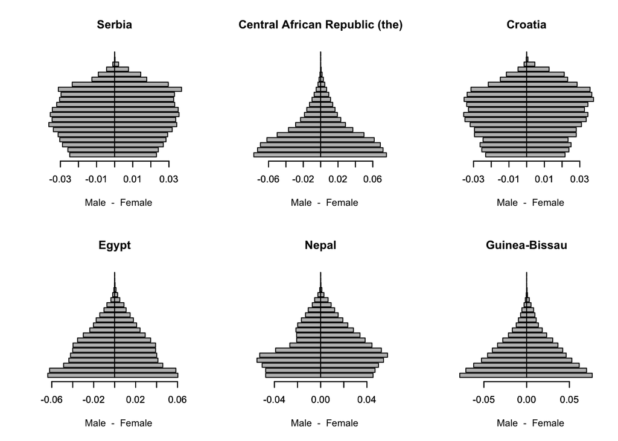

```r
load("PopPyrISO.Rdata")

plot.PopPyrISO <- function(Prop.M.F, label=NULL){
  Prop.M.F <- as.numeric(Prop.M.F)
  n.ages <- length(Prop.M.F)/2
  barplot(-Prop.M.F[1:n.ages], horiz = TRUE,
          main=label,
          xlab="   Male  -  Female",
          xlim=c(-1,1)*max(Prop.M.F))
  barplot(Prop.M.F[n.ages+(1:n.ages)], horiz = TRUE, add=TRUE)
}

n <- dim(PopPyrISO)[1]
op <- par(mfrow=c(2,3))
for (j in sample(n,6))
   plot.PopPyrISO(PopPyrISO[j,(6:47)],PopPyrISO$English.short.name[j])
```

```r
par(op)
```

Using the following function, we compute the distance matrix between two population pyramids using the weighted $L_1$ norm:
$$d(x,y)= \sum_{i=1}^{42}w_i |x_i - y_i|$$
where the vector $w$ of weights is the average population pyramid.

```r
# weighted L1 norm
w.L1 <- function(pop.pyr,alpha=1){
  n<- dim(pop.pyr)[1]
  D.42 <- matrix(0,nrow=n,ncol=n)
  w.age <- apply(pop.pyr,2,mean)^alpha
  w.age <- as.numeric(w.age/sum(w.age))

  A <- as.matrix(pop.pyr)
  as.dist(
    abs( matrix(rep(A,n),nrow=n) -
         matrix(rep(as.numeric(t(A)),n),nrow=n,byrow=TRUE)) %*% kronecker(diag(n),w.age))
}
D.42 <- w.L1(PopPyrISO[,6:47],alpha=1)
```

### 1. Kernel Density Estimation

We aim to identify trends in the gender ratio in the youngest age category. We use Kernel Density Estimation to provide a smooth estimate of the probability density function. We define $X$ as the difference between the percentages of males and females in the range of ages between 0 and 4 years old:

```r
x <- 100*(PopPyrISO$Male.0.4 - PopPyrISO$Female.0.4)
```

The smoothness of the density estimate is controlled by the bandwidth ($h$). To choose the bandwidth we use the Leave-One-Out Likelihood Cross-Validation ($h_{LCV}$) method where, for a given $h$, the likelihood of an observation is calculated using the density estimate derived from all other $n-1$ observations.

We compute this using the Leave-One-Out kernel density estimator at $x_i$:

$$\hat f_{h,(−i)}(x_i)=\frac{n}{n−1}(\hat
f_h(x_i)− \frac{K(0)}{nh})$$

By maximising the logarithm of $\hat f_{h,(−i)}(x_i)$, we find the optimal bandwidth $h_{LCV}$:

```r
vh <- seq(0.02,0.04,by=0.001)
data <- 100*(PopPyrISO$Male.0.4 - PopPyrISO$Female.0.4)

calc_loo_ll <- function(h, x) {
  n <- length(x)

  kx <- density(x, bw=h, n=2048)
  kx_f <- approxfun(x=kx$x, y=kx$y, method='linear', rule=2)
  fESR <- (n/(n-1))*(kx_f(x)-(dnorm(0)/(n*h)))

  return(sum(log(pmax(fESR, 1e-10))))
}

scores <- sapply(vh, calc_loo_ll, x = data)
max_idx <- which.max(scores)
hLCV <- vh[max_idx]
```

The optimal bandwidth is
$$h_{LCV}=0.025.$$

To validate this, we plot the leave-one-out log-likelihood function evaluated over the interval $h \in [0.02,0.04]$:

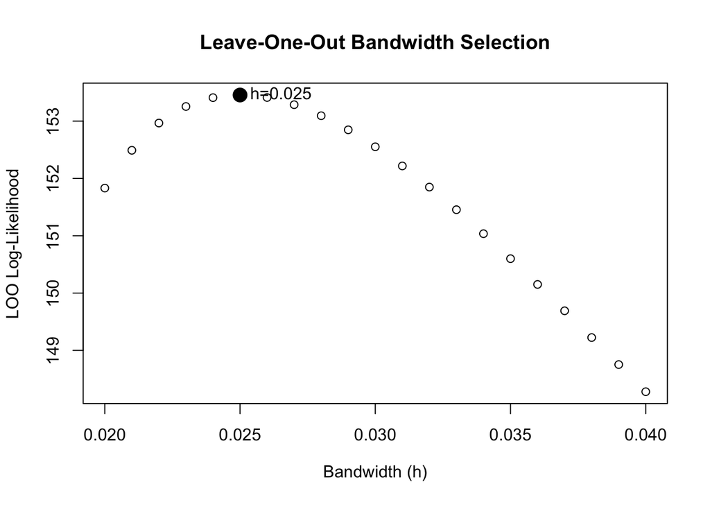

```r
plot(vh, scores, xlab = expression(paste("Bandwidth (",h,")")),
     ylab = "LOO Log-Likelihood",
     main = "Leave-One-Out Bandwidth Selection")

points(hLCV, scores[max_idx], pch = 19, cex = 1.8)
text(hLCV, scores[max_idx], labels = paste0("h=", hLCV), pos = 4)
```

This result allows us to confirm that $h_{LCV}$ represents a maximum, the optimum balance between bias and variance in this interval.

Plotting the kernel density estimator corresponding to $h_{LCV}$:

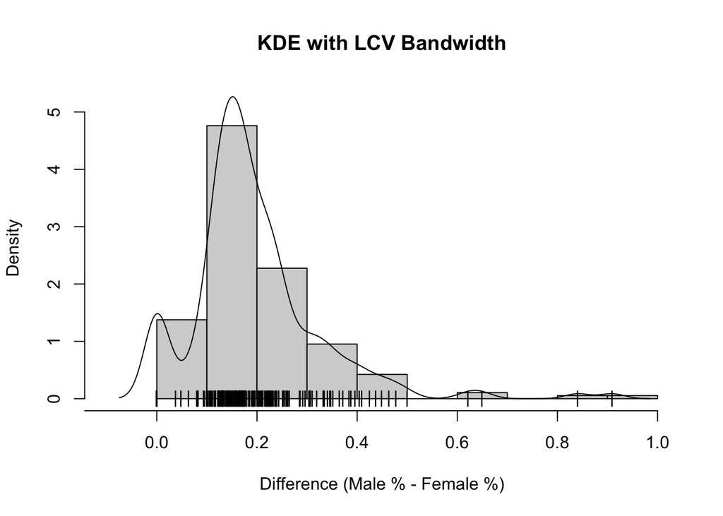

```r
dens <- density(x, bw=hLCV, n=2048)
max_y <- max(dens$y)
hist(x, freq = FALSE, xlim=c(-0.1,1), ylim = c(0, max_y), main = "KDE with LCV Bandwidth", xlab = "Difference (Male % - Female %)", xaxt = "n")
axis(1, at = seq(-0.2, 1, by = 0.2))
lines(density(x, bw=hLCV, n=2048))
points(x,0*x,pch="|")
```

The KDE plot (with the histogram) shows a clear peak between $0.1$ and $0.3$. This represents the most common gender gap across the 189 countries. Since most of the density curve is to the right of zero, we can conclude that there are more males than females in the 0-4 age group in the majority of countries. This is consistent with the real biological sex ratio at birth which slightly favours males. While most countries cluster around this bias, points extending to the right show more extreme imbalances exist.

### 2. Hierarchical clustering

To identify global patterns, we carry out a hierarchical clustering analysis. Using the $L_1$ norm previously computed, we apply Ward’s Hierarchical Clustering Method to group countries into subsets. This method aims to minimize the increase in the sum of squared error from merging two clusters. The list of partitions can be visualised in the dendrogram below:

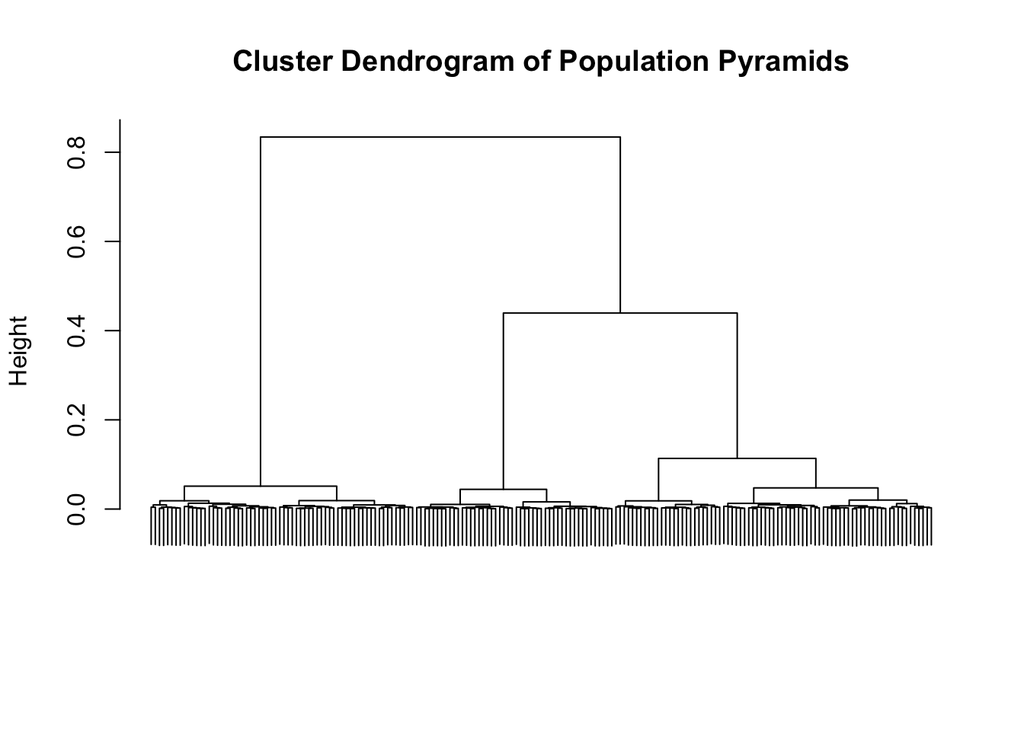

```r
hcl <- hclust(D.42, method="ward.D")
plot(hcl, labels = FALSE, main = "Cluster Dendrogram of Population Pyramids", xlab = "", sub = "")
```

To select the optimal number of clusters $k$, the average silhouette criterion can be used.

```r
library(fpc)
```

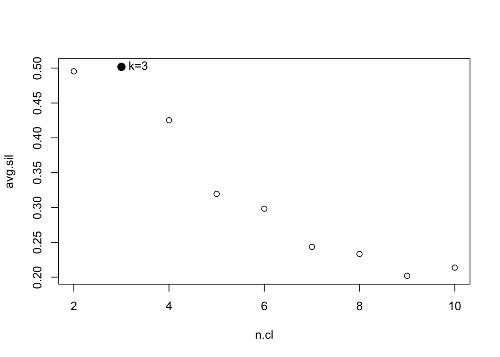

```r
n.cl <- 2:10
l.n.cl<-length(n.cl)

avg.sil <- numeric(l.n.cl)

for (i in (1:l.n.cl)){
  k<-n.cl[i]
  cut.hcl <- cutree(hcl,k)
  cl.stats <- cluster.stats(D.42,cut.hcl)
  avg.sil[i]   <- cl.stats$avg.silwidth
}

plot(n.cl, avg.sil)
best_k <- n.cl[which.max(avg.sil)]
points(best_k, max(avg.sil), pch = 19, cex = 1.4)
text(best_k, max(avg.sil), labels = paste0("k=", best_k), pos = 4)
```

We observe that the optimal clustering number is $k=3$. Thus, the population pyramids are best represented by three demographic types. This suggests using a middle category between extremes ‘young’ vs ‘old’ and, at higher values of $k$, groups become too similar to distinguish between.

### 3. The Silhouette Plot

The silhouette width measures how similar an object is to its own cluster, compared to other clusters. Plotting the silhouette results of the three clusters:

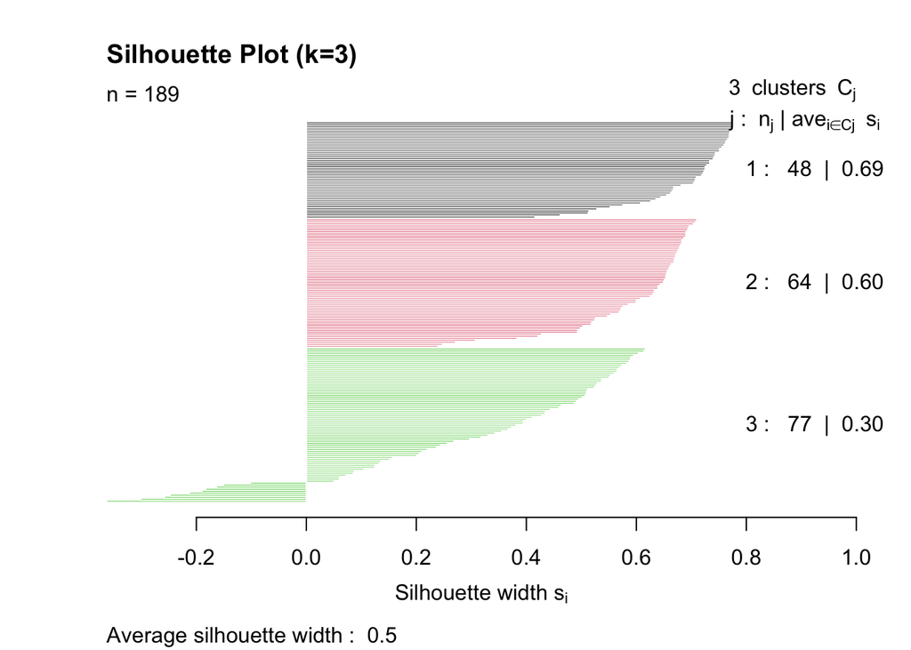

```r
library("cluster")
hcl <- hclust(D.42, method="ward.D")
cut.hcl <- cutree(hcl,best_k)
si <- silhouette(cut.hcl, D.42)
plot(si,col=1:best_k, main="Silhouette Plot (k=3)")
```

First we note that the silhouette analysis confirms that $k=3$ is a reasonable clustering (with average width 0.5). Since values close to 1 indicate a country is well-clustered, we can conclude that Cluster 1 is the strongest cluster with a silhouette width of 0.69. This means almost all countries in this cluster are well-matched and distinct from the other two. However, Cluster 3 has a low score with some negative values - this is likely countries that sit on the border between two demographic types.

### 4. The Average Population Pyramid

Plotting the average population pyramid for each cluster:

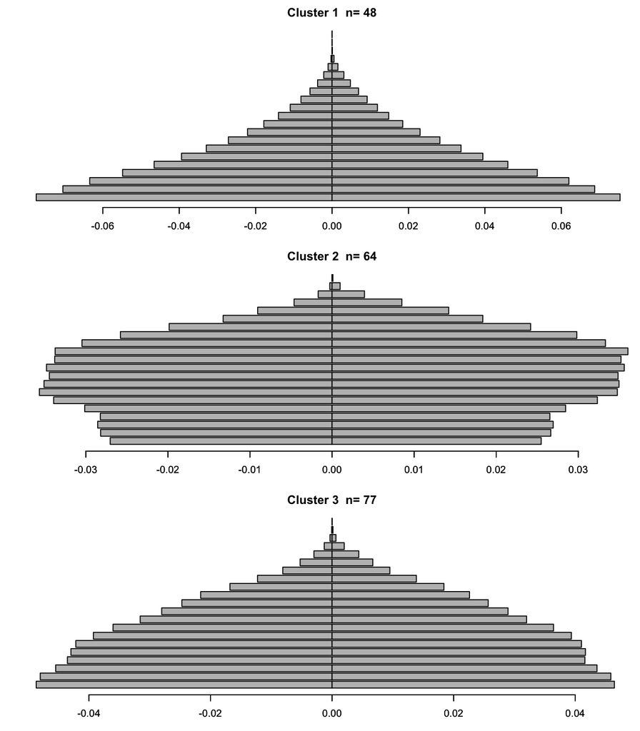

```r
op <- par(mfrow=c(best_k,1), mar = c(3, 3, 2, 1))
for (k in 1:best_k)
  plot.PopPyrISO(colMeans(PopPyrISO[cut.hcl==k, 6:47]), paste("Cluster", k, " n=", sum(cut.hcl==k)))
```

```r
par(op)
```

Cluster 1 shows the most distinctive average shape, consistent with its high silhouette width. The broad base suggests high birth rates and a large youth population. Cluster 2 has a flatter, more uniform average profile, suggesting a compact cluster. Its increased width in the middle suggests a higher aging population, typical of more developed economies. The mean profile for Cluster 3 lies between the other two, which matches its lower silhouette score and confirms it contains borderline countries between the two main patterns. These countries are appearing closer to high-growth or ageing than to a demographic group of their own.

### 5. The World Map

The plot of the world map below represents the three clusters in different colours:

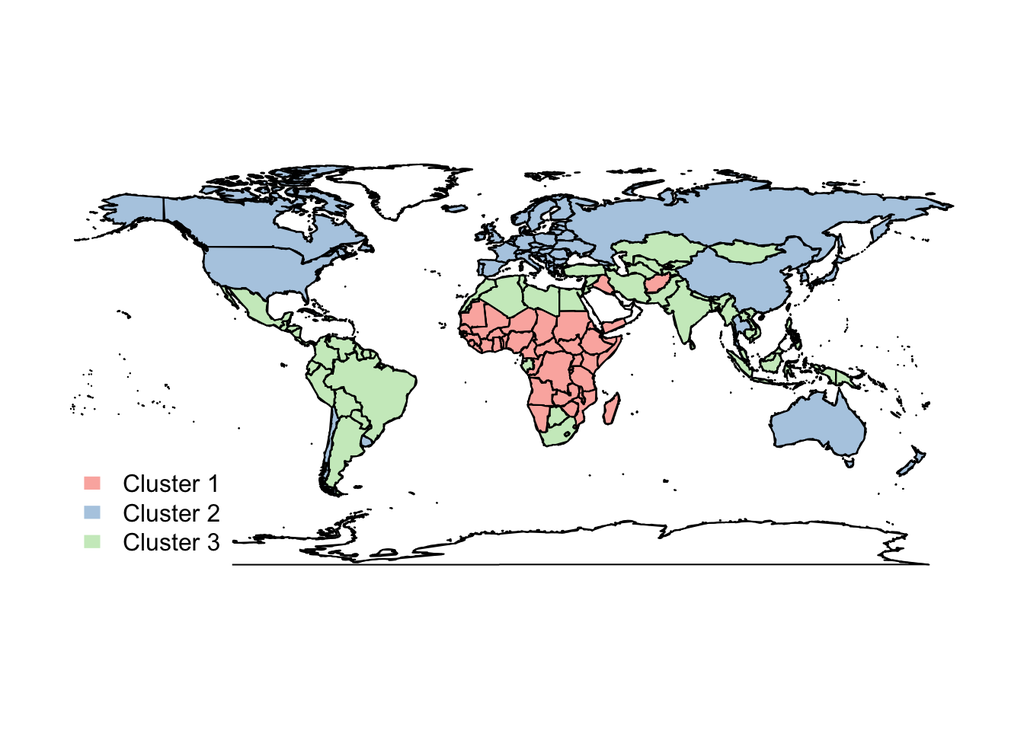

```r
par(mfrow=c(1,1), mar=c(3,3,2,1))
plot_world <- function(Cluster_Indicator,
                       ISO.3.code=PopPyrISO$Alpha.3.code){
  library(maps)
  country.names.world <- iso.expand(ISO.3.code)
  # assigning polygons in "world" to each country
  country.to.map <- match.map("world",country.names.world)
  sum(is.na(country.to.map)); length(country.to.map)

  ncolors <- length(unique(Cluster_Indicator))
  x <- Cluster_Indicator[country.to.map]
  #color <- terrain.colors(n=ncolors)   # with a color palette
  color <- palette.colors(n = ncolors, palette = "pastel 1")
  map("world", fill = TRUE, col = color[x])
  map("world", add = TRUE) # plot again borders
  legend("bottomleft",paste("Cluster",1:ncolors), fill=color[1:ncolors],cex=1,
         border=0,bty="o",box.col=0)
}

cl <- cutree(hcl, best_k)
plot_world(cl)
```

The map demonstrates the different demographic types. Countries geographically closer to each other typically appear in the same cluster. Cluster 1 seems to align with developing nations, whilst cluster 2 represents more developed economies. Cluster 3 appears to represent those that are transitioning.

### 6. k-medoids Clustering

We now carry out clustering of the data using K-medoids clustering and the Calinski and Harabasz index to select $k$:

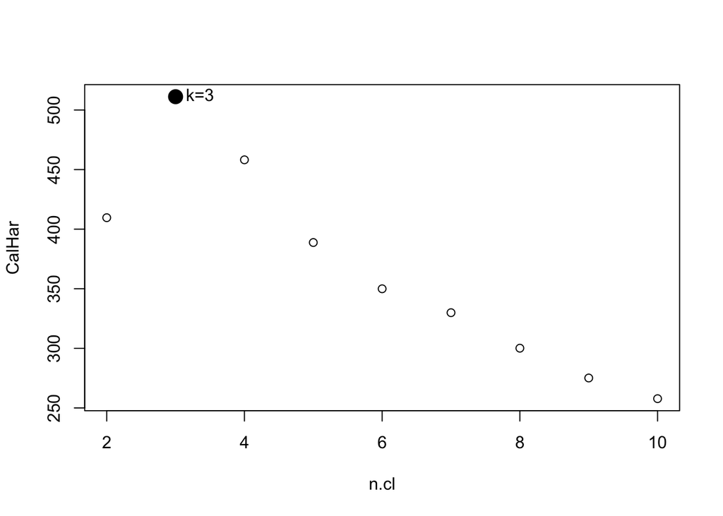

```r
library(cluster)
library(clusterCrit)

library(fpc)
n.cl <- 2:10
l.n.cl<-length(n.cl)
CalHar <- numeric(l.n.cl)

for (i in (1:l.n.cl)){
  k<-n.cl[i]
  kmed <- pam(D.42,k,diss=TRUE)
  cl.stats <- cluster.stats(D.42,kmed$clustering)
  CalHar[i] <- cl.stats$ch
}

plot(n.cl,CalHar)

k <- n.cl[which.max(CalHar)]

points(k, CalHar[which.max(CalHar)], pch = 19, cex = 1.8)
text(k, CalHar[which.max(CalHar)], labels = paste0("k=", k), pos = 4)
```

The Calinski and Harabasz index confirms that $k=3$ is the optimal partition.

### 7. Medoid Country

K-medoids clustering identifies the medoid (most central observation) for each cluster. A medoid minimizes the total dissimilarity to all other members of its cluster. Then, each observation is assigned to the cluster with the closest medoid. We compute the medoid of each cluster and plot the corresponding population pyramid:

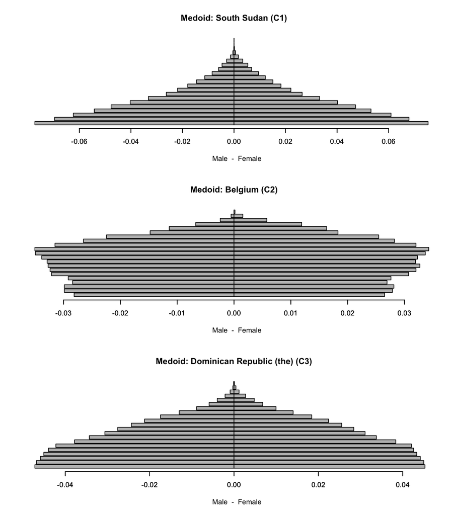

```r
pam_best <- pam(as.matrix(D.42), k = best_k, diss = TRUE)

med_idx <- pam_best$id.med

op <- par(mfrow = c(best_k, 1))
for (g in 1:best_k) {
  j <- med_idx[g]
  plot.PopPyrISO(PopPyrISO[j, 6:47],
                 label = paste0("Medoid: ", PopPyrISO$English.short.name[j], " (C", g, ")"))
}
```

```r
par(op)
```

The cluster 1 medoid is South Sudan. Its pyramid has a very broad base, indicating high fertility. This confirms cluster 1 as the high-growth group. Belgium represents the ageing demographic of cluster 2, with its high proportion of elderly citizens. The Dominican Republic represents the transitional demographic of cluster 3, with a population reaching higher ages than those in cluster 1.

### 8. The World Map (K-medoids method)

We plot the world map using the K-medoids method of clustering:

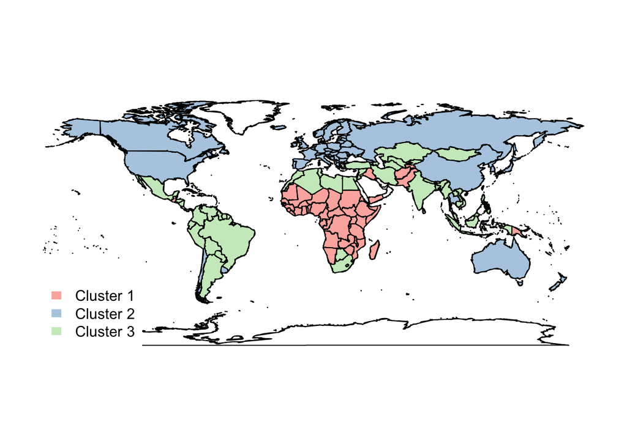

```r
par(mfrow=c(1,1), mar=c(3,3,2,1))

hcl.k.star <- pam_best$clustering
plot_world(hcl.k.star, ISO.3.code = PopPyrISO$Alpha.3.code)
```

This map is nearly identical to the previous hierarchical clustering map. This consistency confirms the three demographic types are clear structures in the data.

### 9. The Cross Table

Computing the cross table of both clustering results:

```r
cl_hcl  <- cutree(hcl, best_k)
cl_pam  <- pam_best$clustering
ct <- table(Hierarchical = cl_hcl, Kmedoids = cl_pam)
ct
```

```
##             Kmedoids
## Hierarchical  1  2  3
##            1 48  0  0
##            2  0 64  0
##            3  7  2 68
```

The cross table shows a very strong agreement between hierarchical clustering and K-medoids: clusters 1 and 2 match perfectly (48/48 and 64/64), while only 9 countries from hierarchical cluster 3 are reassigned by k-medoids (7 to cluster 1 and 2 to cluster 2). This indicates that the clustering structure is stable across methods, with ambiguity concentrated in the third cluster (borderline observations).

## B. Bike-sharing dataset

The file BikeDay.Rdata contains information on the bike-sharing rental service in Washington D.C., USA, corresponding to years 2011 and 2012. This file contains only one data frame, day, with 731 rows (one for each day of years 2011 and 2012, that was a leap year) and 16 columns.

```r
load("BikeDay.Rdata")
head(day)
```

```
##   instant     dteday season yr mnth holiday weekday workingday weathersit
## 1       1 2011-01-01      1  0    1       0       6          0          2
## 2       2 2011-01-02      1  0    1       0       0          0          2
## 3       3 2011-01-03      1  0    1       0       1          1          1
## 4       4 2011-01-04      1  0    1       0       2          1          1
## 5       5 2011-01-05      1  0    1       0       3          1          1
## 6       6 2011-01-06      1  0    1       0       4          1          1
##       temp    atemp      hum windspeed casual registered  cnt
## 1 0.344167 0.363625 0.805833 0.1604460    331        654  985
## 2 0.363478 0.353739 0.696087 0.2485390    131        670  801
## 3 0.196364 0.189405 0.437273 0.2483090    120       1229 1349
## 4 0.200000 0.212122 0.590435 0.1602960    108       1454 1562
## 5 0.226957 0.229270 0.436957 0.1869000     82       1518 1600
## 6 0.204348 0.233209 0.518261 0.0895652     88       1518 1606
```

In particular we are interested in the joint distribution of temp and casual for year 2012:

```r
day2012<-subset(day, yr == 1)
head(day2012[, c("temp", "casual")])
```

```
##         temp casual
## 366 0.370000    686
## 367 0.273043    244
## 368 0.150000     89
## 369 0.107500     95
## 370 0.265833    140
## 371 0.334167    307
```

Here temp is the normalized temperature in Celsius (values are divided to 41, the maximum), while casual is the count of rental bikes by causal users (not registered).

We will treat standardized data:

```r
X <- scale(day2012[, c("temp", "casual")])
```

### 1. Gaussian Mixture Model

Let us do a model based clustering of the dataset X assuming a Gaussian Mixture Model (GMM). We allow varying volume, shape, and orientation for different components in the mixture (VVV model), and choose the number of clusters k=2,…,6 which maximizes the Bayesian Information Criterion (BIC):

$$\mathrm{BIC} = 2 \log L_{\mathrm{max}} - p \log n,$$

where $L_{max}$ is the maximum likelihood of the model (fit to the data), $p$ is the number of free parameters in the model, and $n$ is the number of observations.

We use the following library for mixture clustering:

```r
library(mclust)
```

We use the function Mclust, which fits a GMM to the given data X:

```r
k<-2:6
GMM.VVV<-Mclust(X,G=k, modelNames="VVV")
GMM<-Mclust(X,G=k)
summary(GMM.VVV,parameters=TRUE)
```

```
## ----------------------------------------------------
## Gaussian finite mixture model fitted by EM algorithm
## ----------------------------------------------------
##
## Mclust VVV (ellipsoidal, varying volume, shape, and orientation) model with 3
## components:
##
##  log-likelihood   n df       BIC       ICL
##       -772.7745 366 17 -1645.894 -1677.973
##
## Clustering table:
##   1   2   3
## 111 195  60
##
## Mixing probabilities:
##         1         2         3
## 0.3005604 0.5329386 0.1665010
##
## Means:
##             [,1]        [,2]      [,3]
## temp   -1.107087  0.46765030 0.5016038
## casual -0.958402 -0.04556819 1.8759215
##
## Variances:
## [,,1]
##              temp     casual
## temp   0.18478861 0.03165408
## casual 0.03165408 0.03901672
## [,,2]
##             temp    casual
## temp   0.6450485 0.1064638
## casual 0.1064638 0.1377602
## [,,3]
##              temp     casual
## temp   0.42721973 0.06185038
## casual 0.06185038 0.29435827
```

We obtain a summary of the output from the Mclust function for the VVV model. We observe that the optimal clustering—i.e., the one with the largest BIC for the VVV model—has k = 3 clusters. The summary also provides the number of elements in each cluster (from the hard clustering assignment), the mixing probabilities, and the means and covariance matrices of each mixture component, as well as the total number of observations n and the corresponding BIC.

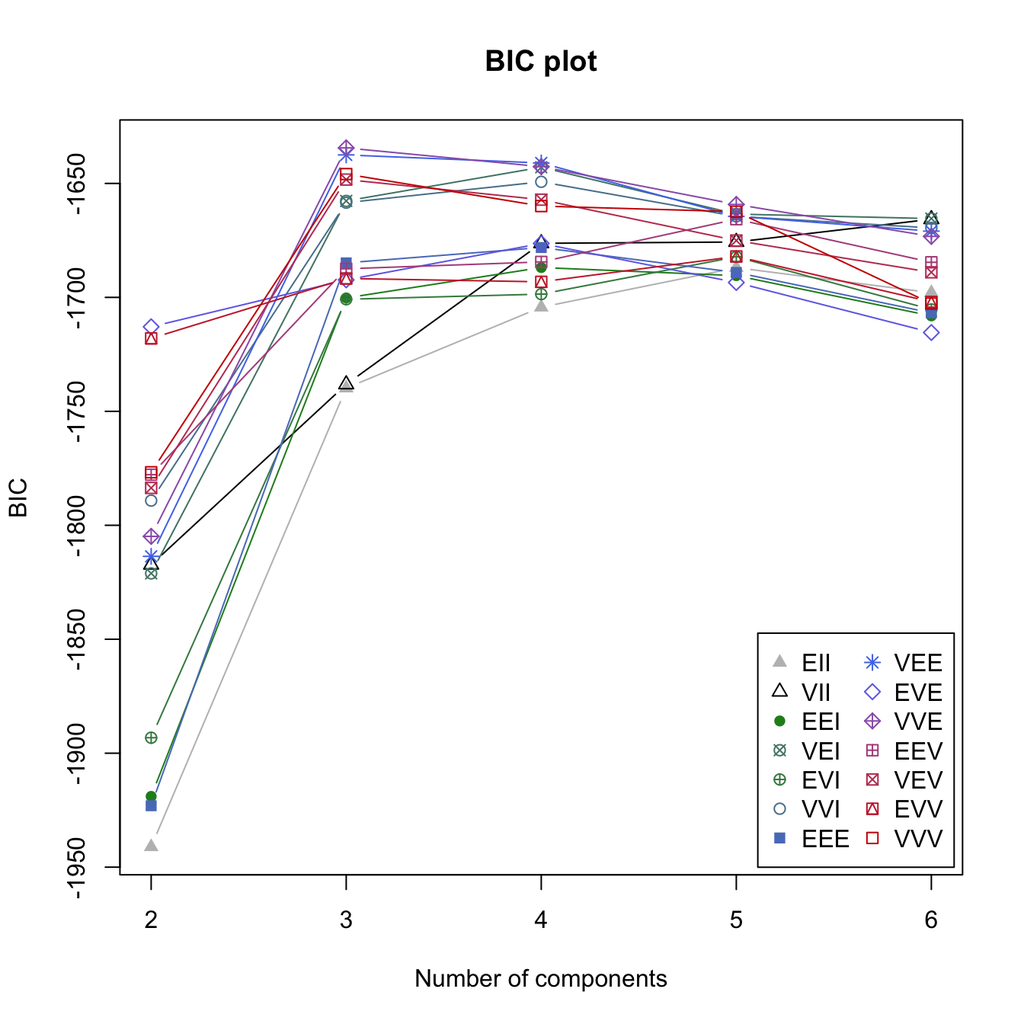

```r
plot(GMM, what="BIC",asp=1)
title("BIC plot")
```

We observe that the model with the largest BIC is VVE (varying volume and shape across clusters but fixed orientation) for k=3. Although VVV is more flexible and achieves a higher likelihood, BIC also accounts for the number of free parameters, penalizing VVV relative to simpler models such as VVE. This is why VVE attains a larger BIC than VVV for this data sample.

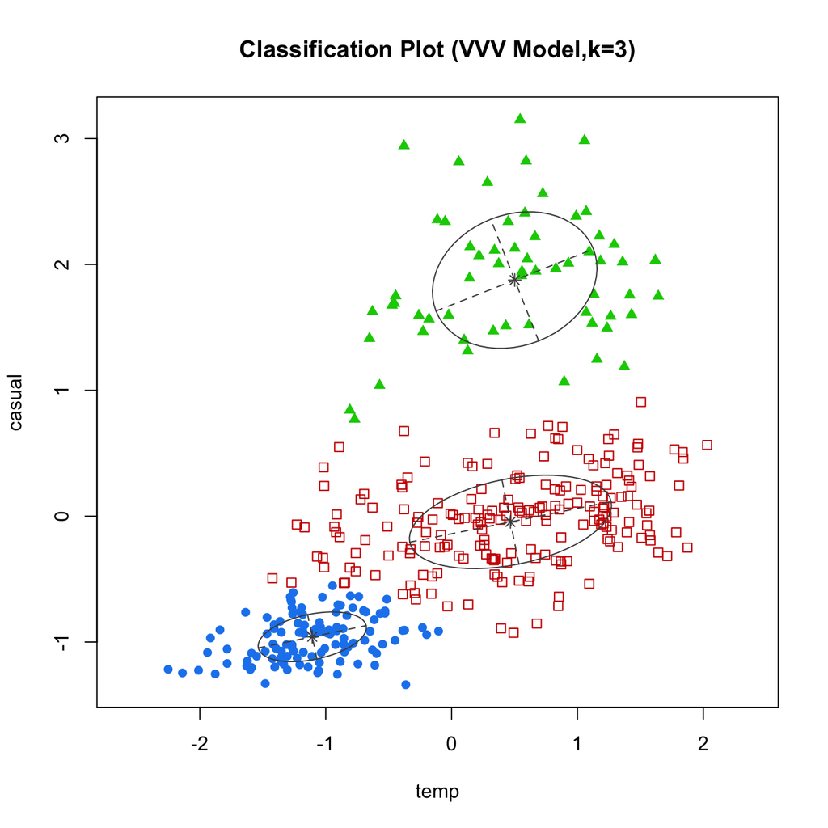

```r
plot(GMM.VVV, what = "classification",asp = 1)
title("Classification Plot (VVV Model,k=3)")
```

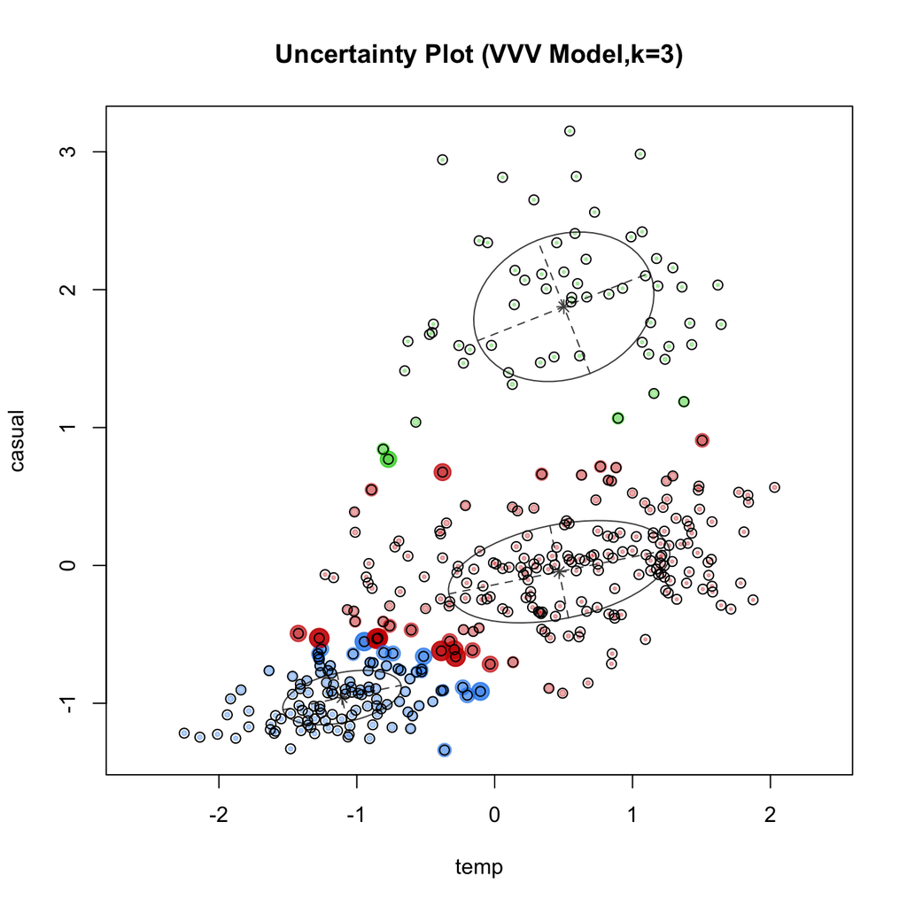

```r
plot(GMM.VVV, what = "uncertainty", asp = 1)
points(X)
title("Uncertainty Plot (VVV Model,k=3)")
```

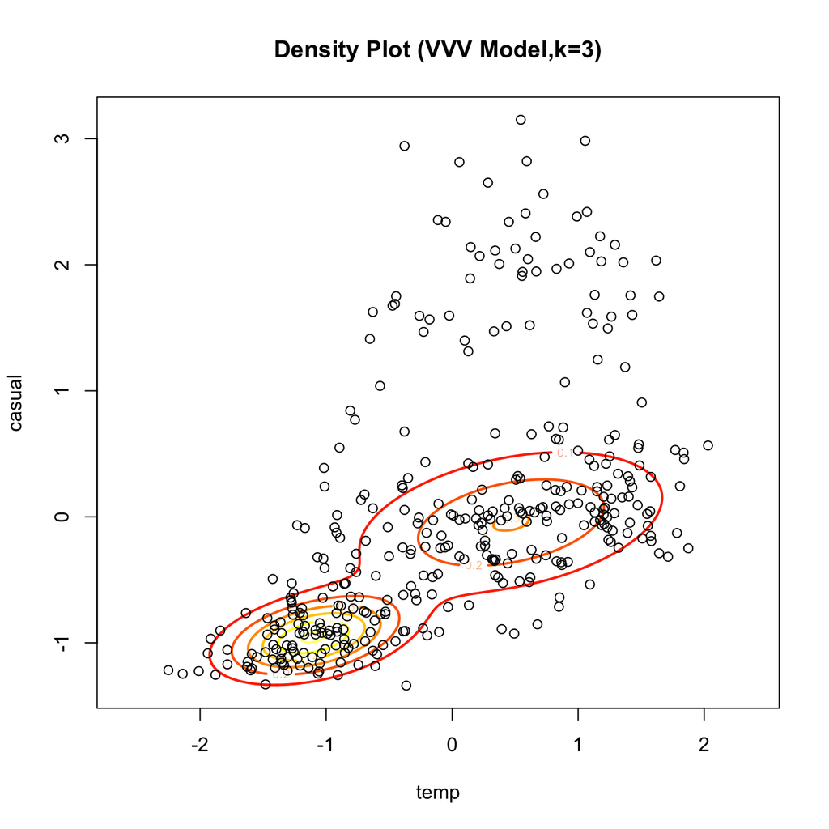

```r
plot(GMM.VVV, what = "density",
     asp=1,
     nlevels=7,
     col=heat.colors(7),
     lwd=2)
points(X)
title("Density Plot (VVV Model,k=3)")
```

### 2. Component Merging

In this section, we check if it is possible to merge some of the components in the Gaussian Mixture Model previously estimated. To do this, we use the library of flexible procedures for clustering:

```r
library(fpc)
```

Precisely, we use the function mergenormals with the option method=“bhat” (some distance method we do not explain here) to obtain a number of clusters k* after a merging process.

```r
cm<-mclustBIC(X,G=3,modelNames="VVV")
scm <- summary.mclustBIC(cm,X)
cmnbhat <- mergenormals(X,scm,method="bhat")
summary(cmnbhat)
```

```
## * Merging Gaussian mixture components *
##
##  Method:  bhat , cutoff value:  0.1
##  Original number of components:  3
##  Number of clusters after merging:  2
##  Values at which clusters were merged:
##      [,1]      [,2]
## [1,]    2 0.1973624
## [2,]    1 0.0751678
##  Components assigned to clusters:
##      [,1]
## [1,]    1
## [2,]    1
## [3,]    2
```

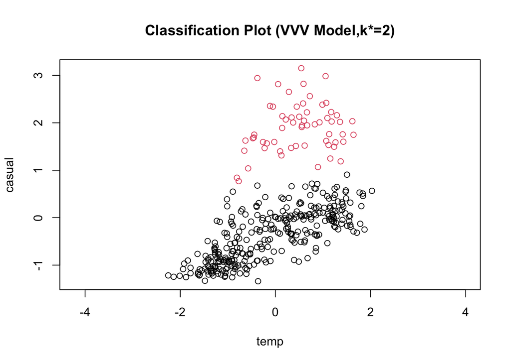

```r
plot(X,col=cmnbhat$clustering, asp = 1)
title("Classification Plot (VVV Model,k*=2)")
```

We observe that k* = 2 and the first two clusters (the denser ones, black observations) are merged together.

### 3. Interpretation

In this final section, we interpret the previous clusterings and relate them to other variables in the dataset.

The last merged clustering has the relevant property that almost all the probability is concentrated in the first cluster, while the second cluster is less probable. Indeed, in the obtained density plot we observe that the highest probability percentiles accumulate in this merged cluster.

This condition can be directly related with some variables given in the dataset: the workingday, which only takes 2 values: 0 if day is either weekend or holiday, otherwise is 1; and the weathersit, which indicates the weather conditions:

1: Clear, Few clouds, Partly cloudy 2: Mist + Cloudy, Mist + Broken clouds, Mist + Few clouds, Mist

If we represent the scatterplot of casual vs temp with colors according to workingday and weathersit, we observe the following:

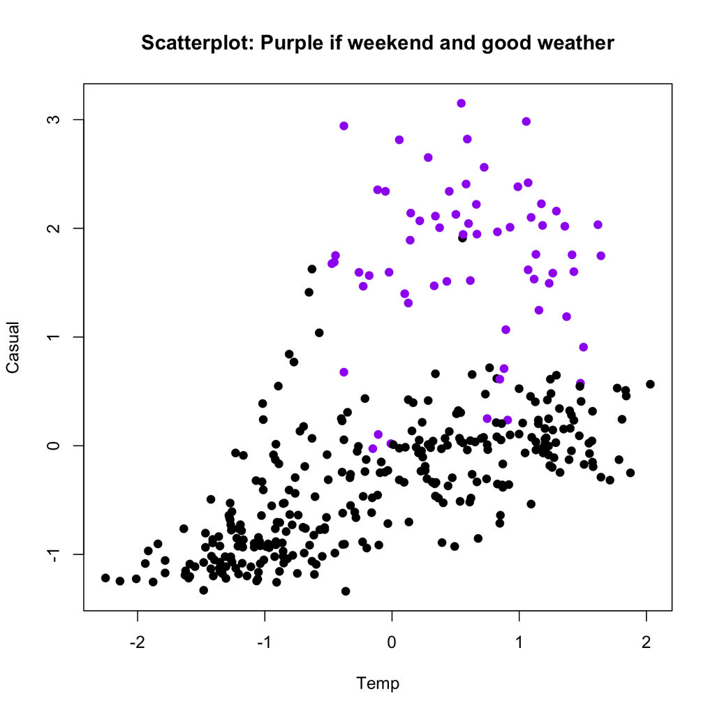

```r
Z <- scale(day2012[, c("temp", "casual")])

cols <- ifelse(day2012$workingday == 0 & Z[,1] > -0.5 & Z[,1] < 1.75 & day2012$weathersit %in% c(1,2) , "purple", "black")
#The weekend and holidays with good weather are denoted by purple dots, and the rest of the days with black dots.
plot(Z[,1], Z[,2],
     col = cols,
     pch = 19,
     xlab = "Temp",
     ylab = "Casual",
     main = "Scatterplot: Purple if weekend and good weather")
```

We observe that the less probable cluster (the third one in the first computed GMM) represents weekend and holiday days with good weather, which are relatively infrequent events in which the number of casual users is unusually high. Here, good weather is defined as no cold temperatures (temp > −0.5 after normalization) but not so hot (temp < 1.75 after normalization), and no precipitation (weathersit = 1 or 2). If we further restrict to weathersit = 1, the number of purple points outside the computed cluster decreases, but some points within the cluster are also excluded.

Let us now examine the other two clusters from the first computed GMM. We note that they primarily contain observations corresponding to working days. To differentiate them, we use another variable in the dataset, season, which takes the values 1, 2, 3, and 4 for winter, spring, summer, and fall, respectively.

Next, we plot a scatterplot of casual versus temp, coloring the points according to season:

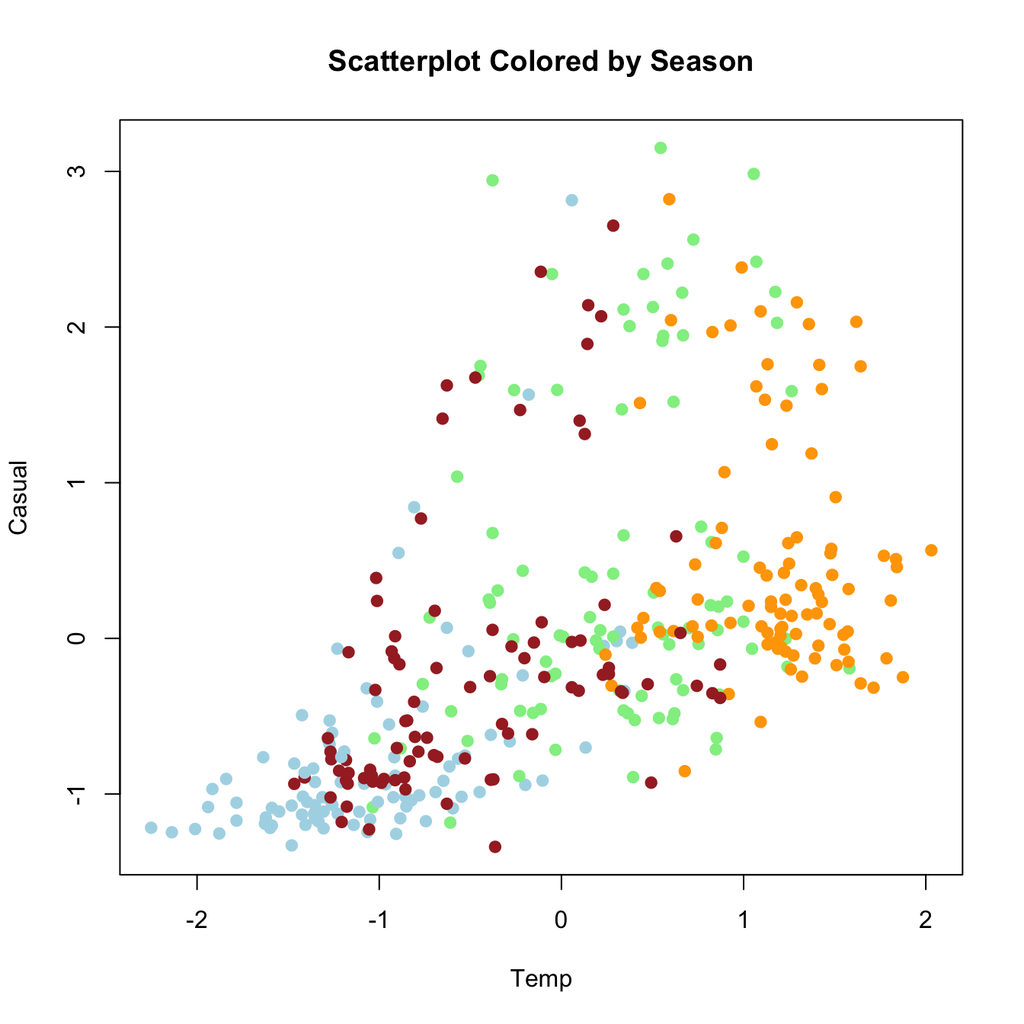

```r
Y <- scale(day2012[, c("temp", "casual", "season")])

groups <- as.factor(Y[,3])

cols <- c("lightblue","lightgreen", "orange", "brown")
#Winter, spring, summer, fall.
plot(Y[,1], Y[,2],
     col = cols[as.numeric(groups)],
     pch = 19,
     xlab = "Temp",
     ylab = "Casual",
     main = "Scatterplot Colored by Season")
```

We observe that the ‘cold’ cluster (blue in the classification plot, with low average temperature) includes winter and fall days, as well as some cold spring days. The mean casual activity in this cluster is low.

In contrast, the ‘hot’ cluster (red in the classification plot, with high average temperature) includes summer days, along with some warm spring, fall, and even winter days. The mean casual activity in this cluster is higher than in the cold cluster